# Machine Learning Portfolio Exam - Classification of Credit Defaults

Felix Haack  
Data Sience  
HAW Kiel WiSe25

> **Note**: xlrd library needs to be installed in the env to run this notebook. Its used read the Excel file from which the datset is imported (although its not explicitly imported at the top cell)

# 1.0 Context

## 1.1 Situation

Our credit card company operates in Taiwan's competitive consumer finance market. Over the past fiscal year, we have observed default rates climbing beyond our expected tolerance threshold for this market. This increase translates to significant unplanned financial losses and threatens our profitability.

Currently, our risk assessment for long term customers relies on a rule-based system developed in 2001 that primarily considers income verification and employment status at the time of application for our credit services. This legacy system focuses only on data known at contract start and fails to incorporate behavioral signals from ongoing account activity—particularly payment patterns that often influence default likelyhood.

Management has approved a series of feasibility studies to evaluate whether machine learning can improve our default risk prediction capabilities using the rich behavioral data we already collect (among others payment history, bill amounts, and repayment behavior). To make sure no insights about the default prediction quality via machine learning algorythms are missed, we start with the earliest data that we have some behavioural features archived for: 2005.

## 1.2 Value

**Loss Prevention**: If we detect a customer that is likely to default we can limit financial damage through proactive interventions such as credit limit reductions, payment plan offers, or increased monitoring.

**Operational Efficiency**: Our current manual review process flags a high amount of customers for human analyst review. A well-calibrated ML model could reduce this to customers with genuinely elevated risk, freeing analyst capacity for higher-value activities.

**Regulatory Compliance**: Taiwan's Financial Supervisory Commission increasingly requires documented, auditable risk assessment processes. Unlike black-box deep learning approaches, the interpretable ML models we evaluate (Decision Trees, K-Nearest Neighbors) can provide clear explanations for credit decisions—essential for regulatory reporting and customer communication.

(see resources 1 to see where this screenshot is from)

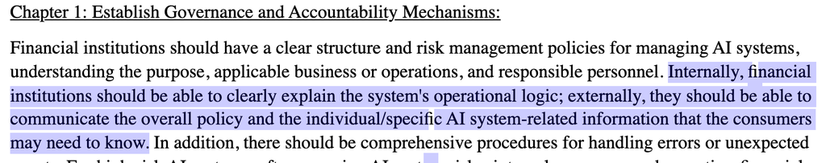

## 1.3 Quality Criteria for Model Evaluation

We select two complementary metrics that reflect our business priorities:

**Primary Metric: ROC-AUC (Area Under the Receiver Operating Characteristic Curve)**

ROC-AUC measures the model's ability to rank customers by default risk across all possible classification thresholds. This is essential because:

- Our operational use case might require *ranking* customers by risk level, not just binary classification. ROC-AUC can provide that if we want to identify the riskiest 10%, 20%, or 30% of customers so that intervention contingent matches intervention capacity.
- ROC-AUC is insensitive to class imbalance (78% non-default vs. 22% default -> see IDA chapter), unlike accuracy which would reward a naive "predict everyone as non-default" strategy.
- It allows comparison across models without committing to a specific decision threshold prematurely.

**Secondary Metric: F1-Score (Macro-Averaged)**

F1-Macro averages the F1-score across both classes equally, providing a balanced view of performance on both defaulters and non-defaulters. We choose this because:

- It penalizes models that achieve high performance on the majority class while neglecting the minority class (defaulters).
- The harmonic mean nature of F1 requires reasonable performance on both precision and recall—we cannot afford to flag too many false positives (damaging customer relationships) nor miss too many true defaults (financial losses).
- Macro-averaging ensures that our minority class (credit default) receives equal weight in evaluation despite its smaller size.

**Why not Recall alone?** While minimizing false negatives (missed defaults) is critical, optimizing purely for recall would flag excessive false positives, overwhelming our intervention capacity and potentially alienating good customers. F1-Macro enforces the necessary balance.

```python
### Imports and global configuration

# Standard library
import time
import warnings

# Data manipulation and visualization
import pandas as pd
import numpy as np
import matplotlib.pyplot as plt
import seaborn as sns


from sklearn.model_selection import learning_curve

# Scikit-learn: Model selection
from sklearn.model_selection import (
    train_test_split,           # Split data into train/test sets
    cross_val_score,            # Simple cross-validation scoring
    cross_val_predict,          # Get CV predictions for visualization
    cross_validate,             # Multi-metric CV in one pass
    learning_curve,             # Learning curve generation to assess overfitting
    StratifiedKFold,            # Stratified K-Fold for imbalanced data
    RepeatedStratifiedKFold,    # Repeated stratified K-Fold
    GridSearchCV                # Grid search for hyperparameter tuning
)

# Scikit-learn: Preprocessing
from sklearn.preprocessing import (
    StandardScaler,             # Standardize features (mean=0, std=1)
    RobustScaler,               # Robust scaling (median/IQR based)
    FunctionTransformer         # Custom transformations
)
from sklearn.compose import ColumnTransformer
from sklearn.pipeline import Pipeline

# Scikit-learn: Models
from sklearn.dummy import DummyClassifier
from sklearn.neighbors import KNeighborsClassifier
from sklearn.tree import DecisionTreeClassifier, plot_tree

# Scikit-learn: Metrics
from sklearn.metrics import (
    roc_auc_score,
    roc_curve,
    auc,
    f1_score,
    confusion_matrix,
    ConfusionMatrixDisplay,
    make_scorer
)

# Scikit-learn: Inspection
from sklearn.inspection import permutation_importance


# Display all columns in DataFrames
pd.set_option("display.max_columns", None)

# Turn off warnings for cleaner output
warnings.filterwarnings("ignore")

# Set random state for reproducibility
RANDOM_STATE = 42
```

## 2.0 The Data

The dataset is the **UCI Credit Card Default Dataset** (https://archive-beta.ics.uci.edu/dataset/350/default+of+credit+card+clients), originally published by Yeh & Lien (2009) and collected from a major bank in Taiwan. It contains payment and billing information for 30,000 credit card customers observed from April to September 2005, with the target variable indicating whether each customer defaulted in October 2005. The dataset is published under the CC BY 4.0 license allowing for the sharing and adaptation of the dataset for any purpose, provided that the appropriate credit is given.

### Why This Dataset?

This dataset is well-suited for our feasibility study because:

1. **Rich behavioral features**: Six months of payment history, bill amounts, and repayment behavior—exactly the signals our legacy system fails to capture yet not too many features to be too complex as a starting point.
2. **Interpretable features**: All variables have clear business meaning and are relatively well documented (we will see limitations to this statement soon). This emeaningfulness of the features enables direct model validation by domain experts and regulatory compliance.
3. **Sufficient sample size**: 30,000 customers provide enough data for reliable cross-validation while remaining computationally manageable.

## Dataset Features

| Variable | Description | Values/Unit |
| --- | --- | --- |
| **default payment next month** | Whether the customer defaulted on payment (this is our target) | 1 = Yes, 0 = No |
| LIMIT_BAL | Amount of given credit (includes individual and family supplementary credit) | New Taiwan Dollar (NT dollar) |
| SEX | Gender of the customer | 1 = male, 2 = female |
| EDUCATION | Education level | 1 = graduate school, 2 = university, 3 = high school, 4 = others |
| MARRIAGE | Marital status | 1 = married, 2 = single, 3 = others |
| AGE | Age of the customer | years |
| PAY_0 | Repayment status in September 2005 | -1 = pay duly, 1-8 = payment delay for 1-9+ months, -2 and 0 also present but meaning is clarified nowhere |
| PAY_2 | Repayment status in August 2005 | -1 = pay duly, 1-8 = payment delay for 1-9+ months, -2 and 0 also present but meaning is clarified nowhere |
| PAY_3 | Repayment status in July 2005 | -1 = pay duly, 1-8 = payment delay for 1-9+ months, -2 and 0 also present but meaning is clarified nowhere |
| PAY_4 | Repayment status in June 2005 | -1 = pay duly, 1-8 = payment delay for 1-9+ months, -2 and 0 also present but meaning is clarified nowhere |
| PAY_5 | Repayment status in May 2005 | -1 = pay duly, 1-8 = payment delay for 1-9+ months, -2 and 0 also present but meaning is clarified nowhere |
| PAY_6 | Repayment status in April 2005 | -1 = pay duly, 1-8 = payment delay for 1-9+ months, -2 and 0 also present but meaning is clarified nowhere |
| BILL_AMT1 | Amount of bill statement in September 2005 | NT dollar |
| BILL_AMT2 | Amount of bill statement in August 2005 | NT dollar |
| BILL_AMT3 | Amount of bill statement in July 2005 | NT dollar |
| BILL_AMT4 | Amount of bill statement in June 2005 | NT dollar |
| BILL_AMT5 | Amount of bill statement in May 2005 | NT dollar |
| BILL_AMT6 | Amount of bill statement in April 2005 | NT dollar |
| PAY_AMT1 | Amount paid in September 2005 | NT dollar |
| PAY_AMT2 | Amount paid in August 2005 | NT dollar |
| PAY_AMT3 | Amount paid in July 2005 | NT dollar |
| PAY_AMT4 | Amount paid in June 2005 | NT dollar |
| PAY_AMT5 | Amount paid in May 2005 | NT dollar |
| PAY_AMT6 | Amount paid in April 2005 | NT dollar |

> Note: One might notice that feature PAY_1 is missing, which could indicate that a gap between the months for PAY_0 and PAY_2 exists. It is however clarified in the Dataset description on the UCI website (features are encoded with enumeration in their description), that feature X6 (PAY_0) represents repayment status for September and feature X7 (PAY_2) represents repayment status for August. It can therefore be considered a typo and will be ignored in the subsequent analysis. (See Additional Variable Information: https://archive.ics.uci.edu/dataset/350/default+of+credit+card+clients)

```python
### Load the credit card default dataset from Excel file

# Note: xlrd library is required to read Excel files (although its not imprted at the top cell)

# header=1: The actual header is in row 2 (0-indexed row 1)
# index_col=0: First column (ID) is used as index
df = pd.read_excel("data/credit_card_defaults.xls", header=1, index_col=0)

# Quick overview of the dataset, to verify it loaded correctly
df.head()
```

| ID | LIMIT_BAL | SEX | EDUCATION | MARRIAGE | AGE | PAY_0 | PAY_2 | PAY_3 | PAY_4 | PAY_5 | PAY_6 | BILL_AMT1 | BILL_AMT2 | BILL_AMT3 | BILL_AMT4 | BILL_AMT5 | BILL_AMT6 | PAY_AMT1 | PAY_AMT2 | PAY_AMT3 | PAY_AMT4 | PAY_AMT5 | PAY_AMT6 | default payment next month |
| --- | --- | --- | --- | --- | --- | --- | --- | --- | --- | --- | --- | --- | --- | --- | --- | --- | --- | --- | --- | --- | --- | --- | --- | --- |
| 1 | 20000 | 2 | 2 | 1 | 24 | 2 | 2 | -1 | -1 | -2 | -2 | 3913 | 3102 | 689 | 0 | 0 | 0 | 0 | 689 | 0 | 0 | 0 | 0 | 1 |
| 2 | 120000 | 2 | 2 | 2 | 26 | -1 | 2 | 0 | 0 | 0 | 2 | 2682 | 1725 | 2682 | 3272 | 3455 | 3261 | 0 | 1000 | 1000 | 1000 | 0 | 2000 | 1 |
| 3 | 90000 | 2 | 2 | 2 | 34 | 0 | 0 | 0 | 0 | 0 | 0 | 29239 | 14027 | 13559 | 14331 | 14948 | 15549 | 1518 | 1500 | 1000 | 1000 | 1000 | 5000 | 0 |
| 4 | 50000 | 2 | 2 | 1 | 37 | 0 | 0 | 0 | 0 | 0 | 0 | 46990 | 48233 | 49291 | 28314 | 28959 | 29547 | 2000 | 2019 | 1200 | 1100 | 1069 | 1000 | 0 |
| 5 | 50000 | 1 | 2 | 1 | 57 | -1 | 0 | -1 | 0 | 0 | 0 | 8617 | 5670 | 35835 | 20940 | 19146 | 19131 | 2000 | 36681 | 10000 | 9000 | 689 | 679 | 0 |

**Note on PAY_X encoding**: The original documentation only defines -1 as "paid duly." The values -2 and 0 are not defined there and no definition can be found in the literature working with this dataset. As demonstrated below, the amount of records with these undefined values is too high to simply remove them from this investigation. This ambiguity will be further addressed in preprocessing (Task 4).

```python
### checking how many -2/0 values we have

# Check the unique values and their frequencies
print(df['PAY_0'].value_counts().sort_index())
```

```
PAY_0
-2     2759
-1     5686
 0    14737
 1     3688
 2     2667
 3      322
 4       76
 5       26
 6       11
 7        9
 8       19
Name: count, dtype: int64
```

## 3.0 IDA

The focus of our IDA is to get a general idea of the datasets scope (e.g. feature ranges, shape, datatypes, target distribution).

### 3.1 Shape and Target distribution

Examining the basic structure of the dataset and the distribution of our target variable.

```python
### Quick look at the data shape
print(f"Dataset shape: {df.shape[0]} samples, {df.shape[1]} features")
print(f"\nTarget distribution:")
print(df['default payment next month'].value_counts(normalize=True))
```

```
Dataset shape: 30000 samples, 24 features

Target distribution:
default payment next month
0    0.7788
1    0.2212
Name: proportion, dtype: float64
```

The dataset contains **30,000 credit card customers** with **24 features** (including the target variable).

The target variable shows a **class imbalance**: approximately 78% of customers did not default, while 22% defaulted on their payment. This imbalance is important to consider when selecting evaluation metrics - accuracy alone would be misleading, which is why we chose ROC-AUC and F1-Macro as our quality criteria in Task 1.

### 3.2 Datatypes, Space in memory, Null values

Examine the data types and check for completeness of each column.

```python
df.info()
```

```
<class 'pandas.core.frame.DataFrame'>
Index: 30000 entries, 1 to 30000
Data columns (total 24 columns):
 #   Column                      Non-Null Count  Dtype
---  ------                      --------------  -----
 0   LIMIT_BAL                   30000 non-null  int64
 1   SEX                         30000 non-null  int64
 2   EDUCATION                   30000 non-null  int64
 3   MARRIAGE                    30000 non-null  int64
 4   AGE                         30000 non-null  int64
 5   PAY_0                       30000 non-null  int64
 6   PAY_2                       30000 non-null  int64
 7   PAY_3                       30000 non-null  int64
 8   PAY_4                       30000 non-null  int64
 9   PAY_5                       30000 non-null  int64
```

[output cut: 16 more lines]

All 24 columns are stored as integers (`int64`), so not datatype tranformations are encessary. Every column has exactly 30,000 non-null entries. This indicates that **no missing values** are present in the dataset. The total memory usage is approximately 5.7 MB, which is very manageable for in-memory processing.

```python
### verify no nan values
print(df.isnull().sum())
```

```
LIMIT_BAL                     0
SEX                           0
EDUCATION                     0
MARRIAGE                      0
AGE                           0
PAY_0                         0
PAY_2                         0
PAY_3                         0
PAY_4                         0
PAY_5                         0
PAY_6                         0
BILL_AMT1                     0
BILL_AMT2                     0
BILL_AMT3                     0
BILL_AMT4                     0
BILL_AMT5                     0
BILL_AMT6                     0
PAY_AMT1                      0
PAY_AMT2                      0
PAY_AMT3                      0
PAY_AMT4                      0
PAY_AMT5                      0
PAY_AMT6                      0
default payment next month    0
dtype: int64
```

As confirmed above, **no missing values exist** in any column. Because it is a very crucial aspect of our dataset and I overlooked missing values with `.info()` in the past, this was double checked.

### 3.3 Feature Ranges and statistics

Examine the statistical properties of all numerical features to understand their distributions, ranges, and potential anomalies.

```python
df.describe()
```

|  | LIMIT_BAL | SEX | EDUCATION | MARRIAGE | AGE | PAY_0 | PAY_2 | PAY_3 | PAY_4 | PAY_5 | PAY_6 | BILL_AMT1 | BILL_AMT2 | BILL_AMT3 | BILL_AMT4 | BILL_AMT5 | BILL_AMT6 | PAY_AMT1 | PAY_AMT2 | PAY_AMT3 | PAY_AMT4 | PAY_AMT5 | PAY_AMT6 | default payment next month |
| --- | --- | --- | --- | --- | --- | --- | --- | --- | --- | --- | --- | --- | --- | --- | --- | --- | --- | --- | --- | --- | --- | --- | --- | --- |
| count | 30000.000000 | 30000.000000 | 30000.000000 | 30000.000000 | 30000.000000 | 30000.000000 | 30000.000000 | 30000.000000 | 30000.000000 | 30000.000000 | 30000.000000 | 30000.000000 | 30000.000000 | 3.000000e+04 | 30000.000000 | 30000.000000 | 30000.000000 | 30000.000000 | 3.000000e+04 | 30000.00000 | 30000.000000 | 30000.000000 | 30000.000000 | 30000.000000 |
| mean | 167484.322667 | 1.603733 | 1.853133 | 1.551867 | 35.485500 | -0.016700 | -0.133767 | -0.166200 | -0.220667 | -0.266200 | -0.291100 | 51223.330900 | 49179.075167 | 4.701315e+04 | 43262.948967 | 40311.400967 | 38871.760400 | 5663.580500 | 5.921163e+03 | 5225.68150 | 4826.076867 | 4799.387633 | 5215.502567 | 0.221200 |
| std | 129747.661567 | 0.489129 | 0.790349 | 0.521970 | 9.217904 | 1.123802 | 1.197186 | 1.196868 | 1.169139 | 1.133187 | 1.149988 | 73635.860576 | 71173.768783 | 6.934939e+04 | 64332.856134 | 60797.155770 | 59554.107537 | 16563.280354 | 2.304087e+04 | 17606.96147 | 15666.159744 | 15278.305679 | 17777.465775 | 0.415062 |
| min | 10000.000000 | 1.000000 | 0.000000 | 0.000000 | 21.000000 | -2.000000 | -2.000000 | -2.000000 | -2.000000 | -2.000000 | -2.000000 | -165580.000000 | -69777.000000 | -1.572640e+05 | -170000.000000 | -81334.000000 | -339603.000000 | 0.000000 | 0.000000e+00 | 0.00000 | 0.000000 | 0.000000 | 0.000000 | 0.000000 |
| 25% | 50000.000000 | 1.000000 | 1.000000 | 1.000000 | 28.000000 | -1.000000 | -1.000000 | -1.000000 | -1.000000 | -1.000000 | -1.000000 | 3558.750000 | 2984.750000 | 2.666250e+03 | 2326.750000 | 1763.000000 | 1256.000000 | 1000.000000 | 8.330000e+02 | 390.00000 | 296.000000 | 252.500000 | 117.750000 | 0.000000 |
| 50% | 140000.000000 | 2.000000 | 2.000000 | 2.000000 | 34.000000 | 0.000000 | 0.000000 | 0.000000 | 0.000000 | 0.000000 | 0.000000 | 22381.500000 | 21200.000000 | 2.008850e+04 | 19052.000000 | 18104.500000 | 17071.000000 | 2100.000000 | 2.009000e+03 | 1800.00000 | 1500.000000 | 1500.000000 | 1500.000000 | 0.000000 |
| 75% | 240000.000000 | 2.000000 | 2.000000 | 2.000000 | 41.000000 | 0.000000 | 0.000000 | 0.000000 | 0.000000 | 0.000000 | 0.000000 | 67091.000000 | 64006.250000 | 6.016475e+04 | 54506.000000 | 50190.500000 | 49198.250000 | 5006.000000 | 5.000000e+03 | 4505.00000 | 4013.250000 | 4031.500000 | 4000.000000 | 0.000000 |
| max | 1000000.000000 | 2.000000 | 6.000000 | 3.000000 | 79.000000 | 8.000000 | 8.000000 | 8.000000 | 8.000000 | 8.000000 | 8.000000 | 964511.000000 | 983931.000000 | 1.664089e+06 | 891586.000000 | 927171.000000 | 961664.000000 | 873552.000000 | 1.684259e+06 | 896040.00000 | 621000.000000 | 426529.000000 | 528666.000000 | 1.000000 |

The statistical description alone already reveals valuable information about our credit customers. These insights (about demographics, etc.) are not just interesting for our company, but give away some implications that will lead our machine learning experiments.

Key observations:

**Credit Limit (LIMIT_BAL):**

- Range from 10,000 to 1,000,000 NT dollars with high variability
- Right-skewed distribution (mean > median)
- *ML implication:* Large range would dominate KNN distance calculations → Scaling will be essential for KNN

**Demographics:**

- SEX: Binary (1=male, 2=female, no other values), mean 1.6 indicates more female customers
- AGE: 21-79 years, mean ~35 years
- EDUCATION: Contains undocumented values. The documentation only defines the values 1-4. The values 0 and 6 (and possibly 5) seem to also be present.
- MARRIAGE: Contains undocumented value 0 (documentation only defines 1-3)
- *ML implication:* The undocumented values will make our analysis (or rather preprocessing) more complex since we need to one-hot-encode these categorical values for a thorough analyisis (exlanation see task 4). How exactly this is handled is discussed task 4.

**Payment Status (PAY_0 to PAY_6):**

- Range -2 to 8 representing payment behavior (-2=no consumption, -1=paid duly, 0=revolving credit, 1-8=months delayed)
- 75th percentile is 0 for all PAY variables → at least 75% of customers pay on time
- *ML implication:* Likely the strongest predictors - past payment behavior is highly indicative of future default. As mentioned above the undocumented values 0 and -2 will need attention in task 4.

**Bill Amounts (BILL_AMT1-6):**

- Contains negative values (min ~-340,000) representing overpayments/credits
- High standard deviations indicate large variability
- *ML implication:* Negative values may indicate responsible customers (less likely to default). High multicollinearity expected between months (redundant information, but acceptable for our algorithms)

**Payment Amounts (PAY_AMT1-6):**

- All non-negative, highly right-skewed (mean >> median)
- Extreme outliers (max ~1.7 million NT dollars)
- *ML implication:* Decision Trees handle skewness well. KNN may be affected by outliers even after scaling, but we accept this limitation instead of removing data

## 4.0 EDA and Preprocessing

1. **Handling undocumented categorical values**: The features `EDUCATION` and `MARRIAGE` contain values (0, 5, 6) not defined in the official documentation. We will investigate these and map them appropriately.
2. **Encoding nominal features**: `SEX`, `EDUCATION`, and `MARRIAGE` are nominal categories without inherent order. One-hot encoding will prevent our algorithms from inferring false ordinal relationships.
3. **Transforming payment status features**: The `PAY_X` variables mix ordinal delay information (1-8 months) with categorical payment behaviors (-2, -1, 0). We will separate these semantically distinct components to improve model performance—particularly for KNN, which relies on meaningful distance calculations.

After preprocessing, we examine feature distributions and correlations with the target variable to further inform our modeling strategy.

### 4.1 Handling undocumented categorical values

The dataset documentation defines `EDUCATION` values 1-4 (graduate school, university, high school, others) and `MARRIAGE` values 1-3 (married, single, others). However, our data contains undocumented values: `EDUCATION` includes 0, 5, and 6, while `MARRIAGE` includes 0.

Since both features have an "others" category (EDUCATION=4, MARRIAGE=3), we consolidate the undocumented values into these existing categories. This preserves all samples while maintaining interpretable feature values.

To verify this consolidation does not distort our data, we compare the target distribution within the "others" category before and after reassignment. A significant shift would indicate that the undocumented values represent a distinct subpopulation—in which case, alternative handling might be warranted.

```python
### Values for EDUCATION and MARRIAGE and Target distribution in others

# What are the value counts for the undefined values in EDUCATION (0,5,6) and MARRIAGE (0)
print(df[['EDUCATION', 'MARRIAGE']].apply(pd.Series.value_counts))

# Safe the target distributions before reassgining undefined values (for visualization of target distributions in these subcategories)
edu_before = (df.loc[df['EDUCATION'] == 4, 'default payment next month'].value_counts(normalize=True))
mar_before= (df.loc[df['MARRIAGE'] == 3, 'default payment next month'].value_counts(normalize=True))

# Target distribution for "others" values before reassgining undefined values
print("\nBefore reassignment target distribution in Education Others:")
print(df.loc[df['EDUCATION'] == 4, 'default payment next month'].value_counts(normalize=True))
print("\nBefore reassignment target distribution in Marriage Others:")
print(df.loc[df['MARRIAGE'] == 3, 'default payment next month'].value_counts(normalize=True))
```

```
   EDUCATION  MARRIAGE
0         14      54.0
1      10585   13659.0
2      14030   15964.0
3       4917     323.0
4        123       NaN
5        280       NaN
6         51       NaN

Before reassignment target distribution in Education Others:
default payment next month
0    0.943089
1    0.056911
Name: proportion, dtype: float64

Before reassignment target distribution in Marriage Others:
default payment next month
0    0.739938
1    0.260062
Name: proportion, dtype: float64
```

```python
### Reassign unknown feature expressions, then show values for EDUCATION and MARRIAGE and Target distribution in others

# Reassign undefined values
df['MARRIAGE'] = df['MARRIAGE'].replace({0: 3})
df['EDUCATION'] = df['EDUCATION'].replace({0: 4, 5: 4, 6: 4})

# Varify the reassignment
print(df[['EDUCATION', 'MARRIAGE']].apply(pd.Series.value_counts))

# Safe the target distributions after reassgining undefined values
edu_after = (df.loc[df['EDUCATION'] == 4, 'default payment next month'].value_counts(normalize=True))
mar_after = (df.loc[df['MARRIAGE'] == 3, 'default payment next month'].value_counts(normalize=True))

# Target distribution for "others" values after reassgining undefined values
print("\nAfter reassignment target distribution in Education Others:")
print(df.loc[df['EDUCATION'] == 4, 'default payment next month'].value_counts(normalize=True))
print("\nAfter reassignment target distribution in Marriage Others:")
print(df.loc[df['MARRIAGE'] == 3, 'default payment next month'].value_counts(normalize=True))
```

```
   EDUCATION  MARRIAGE
1      10585   13659.0
2      14030   15964.0
3       4917     377.0
4        468       NaN

After reassignment target distribution in Education Others:
default payment next month
0    0.929487
1    0.070513
Name: proportion, dtype: float64

After reassignment target distribution in Marriage Others:
default payment next month
0    0.763926
1    0.236074
Name: proportion, dtype: float64
```

From looking at the numbers, we already see that the reassignment only affected very few instances, because most of the dataset has feature expressions for `MARRIAGE`and `EDUCATION` that are unaffected by the reassignment. On top of that the target distribution in the newly formed others instance groups is barely changed from before the reassignment. The effect becomes clear when plotting the distributions:

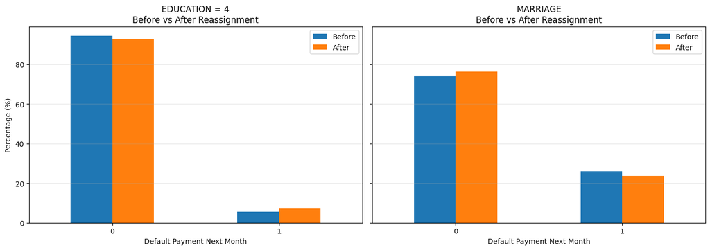

```python
### Visualize the target distributions before and after reassignment from saved values
fig, axes = plt.subplots(1, 2, figsize=(14, 5), sharey=True)

# --------- EDUCATION plot ---------
edu_compare = pd.DataFrame({
    'Before': edu_before,
    'After': edu_after
}).fillna(0) * 100  # Percentage

edu_compare[['Before', 'After']].plot(
    kind='bar',
    ax=axes[0]
)

axes[0].set_title('EDUCATION = 4\nBefore vs After Reassignment')
axes[0].set_xlabel('Default Payment Next Month')
axes[0].set_ylabel('Percentage (%)')
axes[0].tick_params(axis='x', rotation=0)
axes[0].grid(axis='y', alpha=0.3)


# --------- MARRIAGE plot ---------
mar_compare = pd.DataFrame({
    'Before': mar_before,
    'After': mar_after
}).fillna(0) * 100  # Percentage

mar_compare[['Before', 'After']].plot(
    kind='bar',
    ax=axes[1]
)

axes[1].set_title('MARRIAGE\nBefore vs After Reassignment')
axes[1].set_xlabel('Default Payment Next Month')
axes[1].tick_params(axis='x', rotation=0)
axes[1].grid(axis='y', alpha=0.3)


plt.tight_layout()
plt.show()
```

**Reflection:** The reassignment has minimal impact on the dataset for two reasons. First, the undocumented values are rare—even after consolidation, the "others" category remains more than 10 times smaller than the next largest group (high school). Second, the target distribution within "others" shifted only slightly (EDUCATION: 5.7% → 7.1% default rate; MARRIAGE: 26.0% → 23.6%), indicating that the undocumented values do not represent a fundamentally different population.

**One caveat:** We cannot rule out that specific undocumented codes (e.g., EDUCATION=0) might have carried distinct predictive signal. However, with only 14 to 280 samples per code, any patterns would be statistically unreliable and difficult to interpret in a business context. Consolidating these values prioritizes model stability over speculative gains from tiny subgroups.

### 4.2 One-Hot Encoding Nominal Features

The features `SEX`, `EDUCATION`, and `MARRIAGE` are nominal categories with no inherent order. Retaining their integer encoding (e.g., EDUCATION: 1, 2, 3, 4) would introduce spurious ordinal relationships—implying, for instance, that "university" (2) lies between "graduate school" (1) and "high school" (3), or that the distance between categories is uniform and meaningful.

This matters particularly for KNN, which computes distances between samples. With integer encoding, a graduate school customer (EDUCATION=1) would appear "closer" to a university customer (EDUCATION=2) than to someone with "other" education (EDUCATION=4)—a meaningless distinction that could bias neighbor selection.

One-hot encoding resolves this by creating binary indicator columns for each category. All categories become equidistant in feature space, allowing both KNN and Decision Trees to treat them as independent groups without imposed hierarchy.

```python
### One-hot encode categorical features
categorical_cols = ['SEX', 'EDUCATION', 'MARRIAGE']

df = pd.get_dummies(df, columns=categorical_cols, prefix=categorical_cols, dtype=int)

# Verify the one-hot encoding
print(f"Feature count after one-hot encoding: {df.shape[1]}")
print(f"New columns: {[col for col in df.columns if col.startswith(('SEX_', 'EDUCATION_', 'MARRIAGE_'))]}")
df
```

```
Feature count after one-hot encoding: 30
New columns: ['SEX_1', 'SEX_2', 'EDUCATION_1', 'EDUCATION_2', 'EDUCATION_3', 'EDUCATION_4', 'MARRIAGE_1', 'MARRIAGE_2', 'MARRIAGE_3']
```

| ID | LIMIT_BAL | AGE | PAY_0 | PAY_2 | PAY_3 | PAY_4 | PAY_5 | PAY_6 | BILL_AMT1 | BILL_AMT2 | BILL_AMT3 | BILL_AMT4 | BILL_AMT5 | BILL_AMT6 | PAY_AMT1 | PAY_AMT2 | PAY_AMT3 | PAY_AMT4 | PAY_AMT5 | PAY_AMT6 | default payment next month | SEX_1 | SEX_2 | EDUCATION_1 | EDUCATION_2 | EDUCATION_3 | EDUCATION_4 | MARRIAGE_1 | MARRIAGE_2 | … |
| --- | --- | --- | --- | --- | --- | --- | --- | --- | --- | --- | --- | --- | --- | --- | --- | --- | --- | --- | --- | --- | --- | --- | --- | --- | --- | --- | --- | --- | --- | --- |
| 1 | 20000 | 24 | 2 | 2 | -1 | -1 | -2 | -2 | 3913 | 3102 | 689 | 0 | 0 | 0 | 0 | 689 | 0 | 0 | 0 | 0 | 1 | 0 | 1 | 0 | 1 | 0 | 0 | 1 | 0 | … |
| 2 | 120000 | 26 | -1 | 2 | 0 | 0 | 0 | 2 | 2682 | 1725 | 2682 | 3272 | 3455 | 3261 | 0 | 1000 | 1000 | 1000 | 0 | 2000 | 1 | 0 | 1 | 0 | 1 | 0 | 0 | 0 | 1 | … |
| 3 | 90000 | 34 | 0 | 0 | 0 | 0 | 0 | 0 | 29239 | 14027 | 13559 | 14331 | 14948 | 15549 | 1518 | 1500 | 1000 | 1000 | 1000 | 5000 | 0 | 0 | 1 | 0 | 1 | 0 | 0 | 0 | 1 | … |
| 4 | 50000 | 37 | 0 | 0 | 0 | 0 | 0 | 0 | 46990 | 48233 | 49291 | 28314 | 28959 | 29547 | 2000 | 2019 | 1200 | 1100 | 1069 | 1000 | 0 | 0 | 1 | 0 | 1 | 0 | 0 | 1 | 0 | … |
| 5 | 50000 | 57 | -1 | 0 | -1 | 0 | 0 | 0 | 8617 | 5670 | 35835 | 20940 | 19146 | 19131 | 2000 | 36681 | 10000 | 9000 | 689 | 679 | 0 | 1 | 0 | 0 | 1 | 0 | 0 | 1 | 0 | … |
| ... | ... | ... | ... | ... | ... | ... | ... | ... | ... | ... | ... | ... | ... | ... | ... | ... | ... | ... | ... | ... | ... | ... | ... | ... | ... | ... | ... | ... | ... | … |
| 29996 | 220000 | 39 | 0 | 0 | 0 | 0 | 0 | 0 | 188948 | 192815 | 208365 | 88004 | 31237 | 15980 | 8500 | 20000 | 5003 | 3047 | 5000 | 1000 | 0 | 1 | 0 | 0 | 0 | 1 | 0 | 1 | 0 | … |
| 29997 | 150000 | 43 | -1 | -1 | -1 | -1 | 0 | 0 | 1683 | 1828 | 3502 | 8979 | 5190 | 0 | 1837 | 3526 | 8998 | 129 | 0 | 0 | 0 | 1 | 0 | 0 | 0 | 1 | 0 | 0 | 1 | … |
| 29998 | 30000 | 37 | 4 | 3 | 2 | -1 | 0 | 0 | 3565 | 3356 | 2758 | 20878 | 20582 | 19357 | 0 | 0 | 22000 | 4200 | 2000 | 3100 | 1 | 1 | 0 | 0 | 1 | 0 | 0 | 0 | 1 | … |
| 29999 | 80000 | 41 | 1 | -1 | 0 | 0 | 0 | -1 | -1645 | 78379 | 76304 | 52774 | 11855 | 48944 | 85900 | 3409 | 1178 | 1926 | 52964 | 1804 | 1 | 1 | 0 | 0 | 0 | 1 | 0 | 1 | 0 | … |
| 30000 | 50000 | 46 | 0 | 0 | 0 | 0 | 0 | 0 | 47929 | 48905 | 49764 | 36535 | 32428 | 15313 | 2078 | 1800 | 1430 | 1000 | 1000 | 1000 | 1 | 1 | 0 | 0 | 1 | 0 | 0 | 1 | 0 | … |

30000 rows × 30 columns

```python
# reorder columns, since I want to have nominal columns first (I find this more pleasant because it is closer to the original dataframe)

# identify one-hot encoded nominal columns
nominal_cols = [
    col for col in df.columns
    if col.startswith(('SEX_', 'EDUCATION_', 'MARRIAGE_'))
]

# all remaining columns (keep original order)
other_cols = [col for col in df.columns if col not in nominal_cols]

# reorder dataframe
df = df[nominal_cols + other_cols]

df.head()
```

| ID | SEX_1 | SEX_2 | EDUCATION_1 | EDUCATION_2 | EDUCATION_3 | EDUCATION_4 | MARRIAGE_1 | MARRIAGE_2 | MARRIAGE_3 | LIMIT_BAL | AGE | PAY_0 | PAY_2 | PAY_3 | PAY_4 | PAY_5 | PAY_6 | BILL_AMT1 | BILL_AMT2 | BILL_AMT3 | BILL_AMT4 | BILL_AMT5 | BILL_AMT6 | PAY_AMT1 | PAY_AMT2 | PAY_AMT3 | PAY_AMT4 | PAY_AMT5 | PAY_AMT6 | … |
| --- | --- | --- | --- | --- | --- | --- | --- | --- | --- | --- | --- | --- | --- | --- | --- | --- | --- | --- | --- | --- | --- | --- | --- | --- | --- | --- | --- | --- | --- | --- |
| 1 | 0 | 1 | 0 | 1 | 0 | 0 | 1 | 0 | 0 | 20000 | 24 | 2 | 2 | -1 | -1 | -2 | -2 | 3913 | 3102 | 689 | 0 | 0 | 0 | 0 | 689 | 0 | 0 | 0 | 0 | … |
| 2 | 0 | 1 | 0 | 1 | 0 | 0 | 0 | 1 | 0 | 120000 | 26 | -1 | 2 | 0 | 0 | 0 | 2 | 2682 | 1725 | 2682 | 3272 | 3455 | 3261 | 0 | 1000 | 1000 | 1000 | 0 | 2000 | … |
| 3 | 0 | 1 | 0 | 1 | 0 | 0 | 0 | 1 | 0 | 90000 | 34 | 0 | 0 | 0 | 0 | 0 | 0 | 29239 | 14027 | 13559 | 14331 | 14948 | 15549 | 1518 | 1500 | 1000 | 1000 | 1000 | 5000 | … |
| 4 | 0 | 1 | 0 | 1 | 0 | 0 | 1 | 0 | 0 | 50000 | 37 | 0 | 0 | 0 | 0 | 0 | 0 | 46990 | 48233 | 49291 | 28314 | 28959 | 29547 | 2000 | 2019 | 1200 | 1100 | 1069 | 1000 | … |
| 5 | 1 | 0 | 0 | 1 | 0 | 0 | 1 | 0 | 0 | 50000 | 57 | -1 | 0 | -1 | 0 | 0 | 0 | 8617 | 5670 | 35835 | 20940 | 19146 | 19131 | 2000 | 36681 | 10000 | 9000 | 689 | 679 | … |

We can see that the one-hot encoding was successful. The resulting features could be renamed after their original expression meaning (eg. male/female or married/single/others). Our primary focus is however the behavioural part of the dataset and later in our analysis these features will turn out as rather unimportant for predicting the target. Because of this we accept keeping the features in this state despite lowering the intuitive interpretability of the dataset.

### 4.3 Transforming Payment Status Features

The `PAY_X` features (PAY_0 through PAY_6) encode repayment status for each of the six months prior to the prediction window. As this subchapter will show, these are our most predictive features. This makes sense intuitively: past payment behavior strongly signals future default risk. However, the encoding mixes two different types of information:

**Ordinal component (1-8):** Number of months payment is delayed. Here, distances are meaningful—a 3-month delay is worse than a 1-month delay, and the progression is linear.

**Categorical component (-2, -1, 0):** The dataset documentation only defines -1 as "paid in full." The meanings of -2 and 0 are not documented. What we can observe is that all three values represent states distinct from active payment delay—but crucially, they have no natural ordering among themselves. There is no reason to assume -2 < -1 < 0 represents a meaningful progression, yet the integer encoding implies exactly this, which would distort KNN's distance calculations.

**Our approach:** Rather than assuming what -2 and 0 represent, we treat each as a distinct categorical state:

1. Creating binary indicator features (`PAY_X_-2`, `PAY_X_paid_duly(-1)`, `PAY_X_0`) for each of the three non-delay values
2. Transforming the original `PAY_X` to a clean ordinal scale: values ≤ 0 become 0 (not delayed), while values 1-8 remain unchanged (months delayed)

This adds 18 binary features (3 indicators × 6 months) but preserves all information without making assumptions about undocumented values. The model can learn whether -2 and 0 carry predictive signal, even if we cannot interpret their business meaning. Decision Trees can now split directly on these specific states, while KNN benefits from semantically meaningful distances in the ordinal delay component.

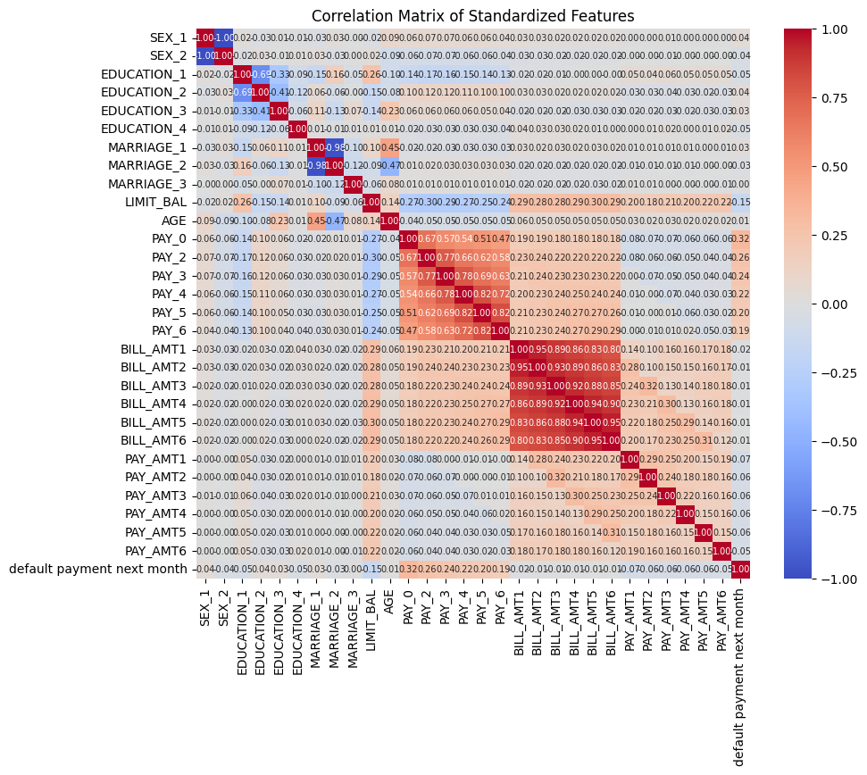

```python
### Calculate and visualize feature correlations with the target

# Generate the correlation matrix to visualize as heatmap, since all features are int64 no preprocessing necessary
correlation_matrix = df.corr()

# Plot correlation as heatmap
plt.figure(figsize=(10, 8))
sns.heatmap(correlation_matrix, annot=True, fmt='.2f', cmap='coolwarm', center=0, annot_kws={"size": 7})
plt.title('Correlation Matrix of Standardized Features')
plt.show()
```

- Looking at this correlation map its becomes clear how high the correlation of the PAY features is with the target variable. We need to closely observe how our tranformation of these features affects the correlation.
- Additionally we can see that a lower limit_bal indicates higher risk of credit default (not important for this subchapter but informative for the project in general).

```python
### PAY feature transformation

# Create list of columns to transform to iterate over
pay_cols = ['PAY_0', 'PAY_2', 'PAY_3', 'PAY_4', 'PAY_5', 'PAY_6']

# Iterate over columns and execute described changes
for col in pay_cols:
    # Create binary indicator features
    df[f'{col}_-2'] = (df[col] == -2).astype(int)
    df[f'{col}_paid_duly(-1)'] = (df[col] == -1).astype(int)
    df[f'{col}_0'] = (df[col] == 0).astype(int)

    # Transform original: map -2, -1, 0 → 0 (not delayed)
    df[col] = df[col].apply(lambda x: 0 if x <= 0 else x)

print(f"New feature count: {df.shape[1]} (was 24, added 6*3=18 binary features)")
```

[output not shown]

```python
### Reorder columns: group PAY features together (PAY_X followed by its binary indicators)
col_order = (
    ['LIMIT_BAL', *nominal_cols, 'AGE'] +
    [f for col in pay_cols for f in [col, f'{col}_-2', f'{col}_paid_duly(-1)', f'{col}_0']] +
    ['BILL_AMT1', 'BILL_AMT2', 'BILL_AMT3', 'BILL_AMT4', 'BILL_AMT5', 'BILL_AMT6'] +
    ['PAY_AMT1', 'PAY_AMT2', 'PAY_AMT3', 'PAY_AMT4', 'PAY_AMT5', 'PAY_AMT6'] +
    ['default payment next month']
)
df = df[col_order]

# Verify new column order
df.head()
```

| ID | LIMIT_BAL | SEX_1 | SEX_2 | EDUCATION_1 | EDUCATION_2 | EDUCATION_3 | EDUCATION_4 | MARRIAGE_1 | MARRIAGE_2 | MARRIAGE_3 | AGE | PAY_0 | PAY_0_-2 | PAY_0_paid_duly(-1) | PAY_0_0 | PAY_2 | PAY_2_-2 | PAY_2_paid_duly(-1) | PAY_2_0 | PAY_3 | PAY_3_-2 | PAY_3_paid_duly(-1) | PAY_3_0 | PAY_4 | PAY_4_-2 | PAY_4_paid_duly(-1) | PAY_4_0 | PAY_5 | PAY_5_-2 | … |
| --- | --- | --- | --- | --- | --- | --- | --- | --- | --- | --- | --- | --- | --- | --- | --- | --- | --- | --- | --- | --- | --- | --- | --- | --- | --- | --- | --- | --- | --- | --- |
| 1 | 20000 | 0 | 1 | 0 | 1 | 0 | 0 | 1 | 0 | 0 | 24 | 2 | 0 | 0 | 0 | 2 | 0 | 0 | 0 | 0 | 0 | 1 | 0 | 0 | 0 | 1 | 0 | 0 | 1 | … |
| 2 | 120000 | 0 | 1 | 0 | 1 | 0 | 0 | 0 | 1 | 0 | 26 | 0 | 0 | 1 | 0 | 2 | 0 | 0 | 0 | 0 | 0 | 0 | 1 | 0 | 0 | 0 | 1 | 0 | 0 | … |
| 3 | 90000 | 0 | 1 | 0 | 1 | 0 | 0 | 0 | 1 | 0 | 34 | 0 | 0 | 0 | 1 | 0 | 0 | 0 | 1 | 0 | 0 | 0 | 1 | 0 | 0 | 0 | 1 | 0 | 0 | … |
| 4 | 50000 | 0 | 1 | 0 | 1 | 0 | 0 | 1 | 0 | 0 | 37 | 0 | 0 | 0 | 1 | 0 | 0 | 0 | 1 | 0 | 0 | 0 | 1 | 0 | 0 | 0 | 1 | 0 | 0 | … |
| 5 | 50000 | 1 | 0 | 0 | 1 | 0 | 0 | 1 | 0 | 0 | 57 | 0 | 0 | 1 | 0 | 0 | 0 | 0 | 1 | 0 | 0 | 1 | 0 | 0 | 0 | 0 | 1 | 0 | 0 | … |

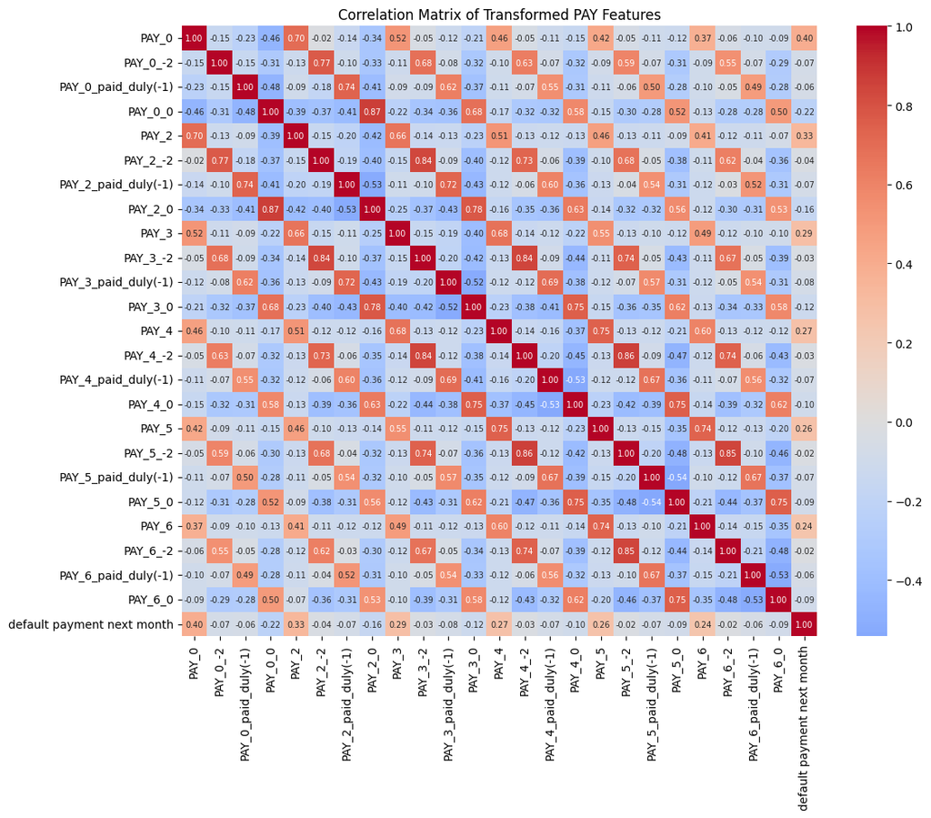

```python
### Select only PAY-related features for correlation analysis, to see how correlation with target has changed after transformation
pay_features = [col for col in df.columns if col.startswith('PAY_') and not col.startswith('PAY_AMT')] + ['default payment next month']

# Calculate correlation matrix for PAY features
pay_correlation = df[pay_features].corr()

# Plot correlation heatmap
plt.figure(figsize=(12, 10))
sns.heatmap(pay_correlation, annot=True, fmt='.2f', cmap='coolwarm', center=0, annot_kws={"size": 7})
plt.title('Correlation Matrix of Transformed PAY Features')
plt.tight_layout()
plt.show()
```

**Reflection:** The correlation matrix confirms that our transformation improved feature quality. The positive correlation between `PAY_X` (now representing only delay months) and the target variable increased after removing the ambiguous negative values. The ordinal delay component now carries a cleaner signal: higher values consistently indicate higher default risk.

The binary indicator features (`-2`, `_paid_duly`, `0`) all show slight negative correlations with default. Without assuming what -2 and 0 specifically mean, we can observe empirically that these non-delay states are associated with lower default probability—useful predictive signal that would have been obscured in the original mixed encoding.

The correlation matrix also reveals temporal autocorrelation typical of behavioral time series: diagonal bands of high correlation indicate that payment behavior persists across months. A customer who paid late in August likely paid late in July as well. This explains why `PAY_0` (most recent month) shows the strongest correlation with default (0.40), while earlier months show progressively weaker correlations (`PAY_6`: 0.24). Recent behavior is simply more predictive of near-future behavior.

### 4.4 Credit Limit (LIMIT_BAL): Skewed Distribution and Correlation with Default Risk

Credit limit is the single continuous feature in our dataset that reflects our bank's prior risk assessment of each customer. Unlike payment history (which captures customer behavior), `LIMIT_BAL` represents a value the experts at our bank set—banks typically assign higher limits to customers they deem lower risk based on income, credit history, and other factors at account opening.

This makes `LIMIT_BAL` particularly interesting: if lower credit limits correlate with higher default rates, it may indicate either (a) that the bank's original risk assessment has predictive validity, or (b) that customers with lower limits face tighter financial constraints that increase default probability.

We examine the distribution separated by default status to assess whether credit limit carries predictive signal independent of payment behavior, and to understand the skewness identified in our descriptive statistics—which has implications for feature scaling in KNN.

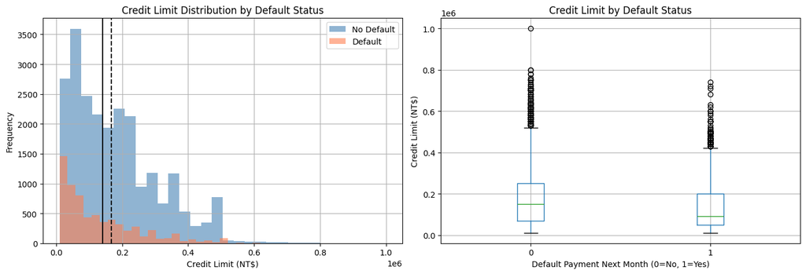

```
LIMIT_BAL Statistics:
  Mean:        167,484 NT$
  Median:      140,000 NT$
  Skew:           0.99 (positive = right-skewed)
```

```python
fig, axes = plt.subplots(1, 2, figsize=(14, 5))

# Plot 1: Overlapping histograms by default status
ax1 = axes[0]
df[df['default payment next month'] == 0]['LIMIT_BAL'].hist(
    ax=ax1, bins=30, alpha=0.6, label='No Default', color='steelblue'
)
df[df['default payment next month'] == 1]['LIMIT_BAL'].hist(
    ax=ax1, bins=30, alpha=0.6, label='Default', color='coral'
)
ax1.set_xlabel('Credit Limit (NT$)')
ax1.set_ylabel('Frequency')
ax1.set_title('Credit Limit Distribution by Default Status')
ax1.legend()
ax1.axvline(df['LIMIT_BAL'].mean(), color='black', linestyle='--', label=f'Mean: {df["LIMIT_BAL"].mean():,.0f}')
ax1.axvline(df['LIMIT_BAL'].median(), color='black', linestyle='-', label=f'Median: {df["LIMIT_BAL"].median():,.0f}')

# Plot 2: Box plot comparison
ax2 = axes[1]
df.boxplot(column='LIMIT_BAL', by='default payment next month', ax=ax2)
ax2.set_xlabel('Default Payment Next Month (0=No, 1=Yes)')
ax2.set_ylabel('Credit Limit (NT$)')
ax2.set_title('Credit Limit by Default Status')
plt.suptitle('')  # Remove automatic title from boxplot

plt.tight_layout()
plt.show()

# Print summary statistics
print("LIMIT_BAL Statistics:")
print(f"  Mean:   {df['LIMIT_BAL'].mean():>12,.0f} NT$")
print(f"  Median: {df['LIMIT_BAL'].median():>12,.0f} NT$")
print(f"  Skew:   {df['LIMIT_BAL'].skew():>12.2f} (positive = right-skewed)")
```

**Observations:**

The distribution is right-skewed (skewness = 0.99), with most customers having credit limits below 200,000 NT$ while a long tail extends up to 1,000,000 NT$. The mean (167,484 NT$) exceeds the median (140,000 NT$), confirming the skewness.

Comparing default vs. non-default customers reveals an important pattern: defaulters (orange) are more concentrated at lower credit limits, with their distribution peaking around 50,000 NT$. Non-defaulters (blue) show a broader distribution extending to higher credit limits. The boxplot confirms this—defaulters have a lower median credit limit and fewer high-value outliers.

This suggests that lower credit limits correlate with higher default risk. We can therefore expect it to play an imprtant role in our predictions beside the behavioural features.

**ML Implications:** The skewness affects our algorithms differently. KNN relies on distance calculations, and StandardScaler—which uses mean and standard deviation—is sensitive to outliers. After scaling, most values cluster tightly while outliers create extreme distances that can dominate neighbor selection. RobustScaler, which uses median and interquartile range, would mitigate this issue. Decision Trees are unaffected by skewness since they simply find optimal split thresholds (e.g., LIMIT_BAL > 150,000) regardless of distribution shape.

### 4.5 Splitting Learning Data and Target

Before starting with the ML experiments we need to seperate the target variable from the learning data.

```python
# Separate features (X) and target variable (y)
# We drop the target column from X and store it separately in y
X = df.drop(columns=['default payment next month'])  # All columns except target
y = df['default payment next month']                 # Binary target: 0 = no default, 1 = default

# Verify shapes
print(f"Feature matrix shape: {X.shape}")
print(f"Target vector shape: {y.shape}")
```

```
Feature matrix shape: (30000, 47)
Target vector shape: (30000,)
```

## 5.0 First Impressions

**Baseline (B):** We use a stratified random classifier that predicts class labels according to the training set's class distribution. This represents the performance we would expect from random guessing while respecting class imbalance—any useful model must substantially outperform this baseline.

**Algorithm A1 - K-Nearest Neighbors (KNN):** A distance-based algorithm that classifies samples based on the majority class among their k nearest neighbors.

*Preprocessing requirements:*

- **Feature scaling is essential.** KNN computes Euclidean distances, so features with larger ranges (e.g., LIMIT_BAL: 10,000-1,000,000) would dominate features with smaller ranges (e.g., AGE: 21-79). We apply RobustScaler to scale the data while taking into account that outliers might distort scaling with methods like standard scaler.
- Our one-hot encoded and binary indicator features are already on a 0/1 scale, but scaling ensures consistency across all features.

**Algorithm A2 - Decision Tree:** A rule-based algorithm that recursively partitions the feature space using threshold-based splits.

*Preprocessing requirements:*

- **No scaling required.** Decision Trees are invariant to monotonic transformations of features since they only consider relative ordering for split decisions.
- One-hot encoding (already applied) allows the tree to split on individual categories rather than arbitrary numeric thresholds.

```python
### Train-test split (80/20, stratified to preserve class distribution)
X_train, X_test, y_train, y_test = train_test_split(
    X, y,
    test_size=0.2,
    random_state=RANDOM_STATE,
    stratify=y
)

print(f"Training set: {X_train.shape[0]} samples")
print(f"Test set:     {X_test.shape[0]} samples")
print(f"Class distribution preserved: {y_test.mean():.1%} default rate in test set")
```

```
Training set: 24000 samples
Test set:     6000 samples
Class distribution preserved: 22.1% default rate in test set
```

```python
### Fitting algorithms and baseline

# --- Baseline: Stratified Random Classifier ---
baseline = DummyClassifier(strategy='stratified', random_state=RANDOM_STATE)
baseline.fit(X_train, y_train)

# --- KNN: With feature scaling ---
scaler = RobustScaler()
X_train_scaled = scaler.fit_transform(X_train)
X_test_scaled = scaler.transform(X_test)

knn = KNeighborsClassifier()  # default: n_neighbors=5, weights='uniform'
knn.fit(X_train_scaled, y_train)

# --- Decision Tree: No scaling needed ---
dt = DecisionTreeClassifier(random_state=RANDOM_STATE)  # default: no max_depth
dt.fit(X_train, y_train)
```

```
DecisionTreeClassifier(random_state=42)
```

```python
### 5.4 Evaluation on the test set and comparison in table

def evaluate_model(model, X_test, y_test, model_name):
    """Evaluate model and return metrics dictionary."""
    y_pred = model.predict(X_test)
    y_proba = model.predict_proba(X_test)[:, 1]

    return {
        'Model': model_name,
        'ROC-AUC': roc_auc_score(y_test, y_proba),
        'F1-Macro': f1_score(y_test, y_pred, average='macro')
    }

# Evaluate all models (note: KNN uses scaled test data)
results = pd.DataFrame([
    evaluate_model(baseline, X_test, y_test, 'Baseline (Stratified)'),
    evaluate_model(knn, X_test_scaled, y_test, 'KNN (default)'),
    evaluate_model(dt, X_test, y_test, 'Decision Tree (default)')
])

# The Decision Tree is likely overfitting in default mode so we print these statistics to confirm
print(f"\nDecision Tree Statistics:")
print(f"  Total nodes: {dt.tree_.node_count}")
print(f"  Max depth: {dt.get_depth()}")
print(f"  Number of leaves: {dt.get_n_leaves()}")

results
```

```
Decision Tree Statistics:
  Total nodes: 7523
  Max depth: 40
  Number of leaves: 3762
```

|  | Model | ROC-AUC | F1-Macro |
| --- | --- | --- | --- |
| 0 | Baseline (Stratified) | 0.495135 | 0.495118 |
| 1 | KNN (default) | 0.710417 | 0.655646 |
| 2 | Decision Tree (default) | 0.603626 | 0.600228 |

> **About the Metrics**: ROC-AUC (Area Under the Receiver Operating Characteristic Curve) measures a model's ability to rank positive cases (defaulters) higher than negative cases (non-defaulters) across all classification thresholds. A score of 0.5 indicates random ranking—no better than guessing—while 1.0 represents perfect separation. F1-Macro is the unweighted average of F1-scores for both classes, where F1 itself is the harmonic mean of precision and recall. This metric penalizes models that perform well on one class while neglecting the other.

**Baseline (Stratified):** Both metrics hover around 0.50, confirming that random guessing according to class distribution provides no predictive value. This establishes our lower bound—any useful model must substantially exceed these scores.

**KNN (default, k=5):** With ROC-AUC of 0.71, KNN demonstrates meaningful predictive ability. A score of 0.71 means that when we randomly select one defaulter and one non-defaulter, KNN ranks the defaulter as higher risk 70% of the time. The F1-Macro of 0.65 indicates reasonable balance between precision and recall across both classes, though there is room for improvement.

**Decision Tree (default, unlimited depth):** The lower scores (ROC-AUC: 0.6, F1-Macro: 0.6) are very certainly due to overfitting. Without depth constraints, the tree memorizes training data patterns that do not generalize to unseen data. The gap between Decision Tree and KNN performance should narrow—or even reverse—after hyperparameter tuning in Task 6, where limiting tree depth will improve generalization.

**Key Takeaway:** Both algorithms substantially outperform the baseline, confirming that our preprocessed features contain predictive signal for credit default. However, these results are based on a single train-test split and may vary with different random partitions. Cross-validation will provide more robust estimates.